# 20대 남녀 취업자 추세 분석을 이용한 예측 (1차 보고서)

2023-05-08

## 1. 개요

#### (1) 분석 목적

- 20대 남녀 취업자 추세 분석
- 본 프로젝트는 KOSIS에서 제공하는 성/연령별 취업자 수 데이터로 2005년 1월부터 2022년 12월까지의 20대 남/녀 취업자 수 활용해 시계열 분석을 하고자 한다.
- 본 1차 보고서는 평활법, 분해법을 활용해 로우 데이터 상태에서 탐색적 분석을 목적으로 한다.

#### (2) 시계열 자료 설명

- 데이터 출처: KOSIS 제공한 성/연령별 취업자 데이터
- 활용 데이터 개요: 2005년 1월 ~ 2022년 12월까지의 시점. 컬럼은 취업자 수 (단위 천 명), 시점 (월별)으로 구성된 남녀 각각의 일변량 데이터로 두 데이터 모두 216행 2열로 구성되어 있다.
- 사용할 데이터프레임 형태는 아래 그림과 같다. (참고: 아래 데이터프레임은 남성과 여성을 분리하기 이전의 데이터)

```r
library(readxl)
library(forecast)
library(TTR)
library(tseries)
wm = read_excel("C:/박규영/4학년_1학기/시계열/조별과제/과제데이터.xlsx")
wm <- head(wm, n = nrow(wm) - 3) # 2005년 1월 ~ 2022년 12월까지 고려하기 위해
man = ts(data=wm[,2], frequency=12, start=c(2005,1))
woman = ts(data=wm[,3], frequency=12, start=c(2005,1))
max_w <- max(woman)
head(wm)
```

```
## # A tibble: 6 × 3
##   시점     남자  여자
##   <chr>   <dbl> <dbl>
## 1 2005.01  2069  2197
## 2 2005.02  2068  2213
## 3 2005.03  2044  2226
## 4 2005.04  2046  2210
## 5 2005.05  2046  2246
## 6 2005.06  2047  2236
```

#### (3) 시계열 자료 특징

- 기술통계량 요약
- 남성의 경우, 표본평균은 1806이다.
- 여성의 경우, 표본평균은 1959이다.

```r
summary(man)
```

```
##       남자
##  Min.   :1631
##  1st Qu.:1743
##  Median :1777
##  Mean   :1806
##  3rd Qu.:1862
##  Max.   :2069
```

```r
summary(woman)
```

```
##       여자
##  Min.   :1767
##  1st Qu.:1880
##  Median :1927
##  Mean   :1959
##  3rd Qu.:2015
##  Max.   :2255
```

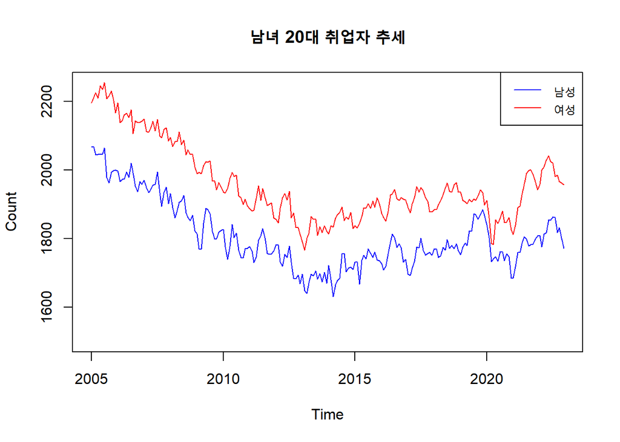

```r
plot(man, col="blue", main="남녀 20대 취업자 추세", ylab='Count', ylim=c(1500, max_w))
lines(woman, col="red")
legend("topright", legend=c("남성", "여성"), col=c("blue", "red"), lty=1)
```

## 2. 추세 분석

- 추세분석을 사용하여 전체적인 시계열의 특징들을 파악할 수 있다.
- 특히 그중에서도 추세분석에서 가장 많이 사용하는 회귀분석 기법을 이용하여 데이터의 추세 및 가장 적합한 회귀 모형이 무엇인지에 대하여 분석해보고자 한다.

#### (1) 회귀를 이용한 추세 분석 (남성)

- 시계열 그래프 개형을 살펴봤을 때, 직선적인 추세를 띠고 있지 않아서 2차 회귀분석부터 4차, 그리고 3차 회귀에 로그변환을 적용한 모형까지 고려해보았다.

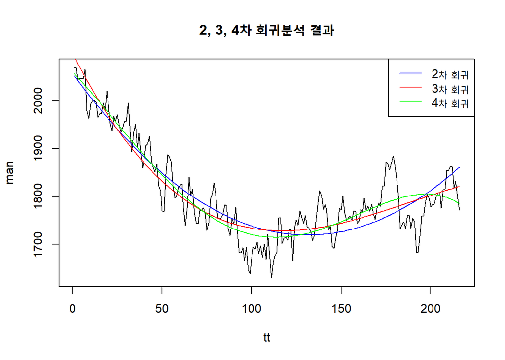

```r
tt = 1:length(man) # 설명변수
reg1 = lm(man~tt+I(tt^2))
reg2 = lm(man~tt+I(tt^2)+I(tt^3))
reg3 = lm(man~tt+I(tt^2)+I(tt^3)+I(tt^4))

plot(tt, man, main='2, 3, 4차 회귀분석 결과',type="l")
lines(reg1$fitted.values, col="blue")
lines(reg2$fitted.values, col="red")
lines(reg3$fitted.values, col="green")
legend("topright", legend=c("2차 회귀", "3차 회귀", "4차 회귀"), col=c("blue", "red", "green"), lty=1)
```

- 회귀모형의 유의성검정
- 2차, 3차, 4차 다항회귀분석에 대하여 추세분석을 진행한 후 각각 독립변수들이 유의한 결과가 나오는지를 확인하기 위해 유의성 검정을 실시하였다.
- 유의수준 0.05하에서 2차, 3차 회귀분석은 모든 변수들이 유의한 결과가 나오는 것을 확인할 수 있지만 4차 회귀분석에서는 이차항 독립변수가 유의하지 않은 결과가 나오는 것을 확인할 수 있다.
- 따라서 해당 데이터에 대해서는 3차 모형까지가 적합한 모형으로 판단한 후 3차모형에 로그변환을 한 것까지 같이 비교해 보았다.

```r
sreg1 = summary(reg1) # 2차
sreg2 = summary(reg2) # 3차
sreg3 = summary(reg3) # 4차

print(sreg1$coefficients)
```

```
##                  Estimate   Std. Error   t value      Pr(>|t|)
## (Intercept) 2056.51622956 8.8810417959 231.56250 7.125641e-258
## tt            -5.12586102 0.1889770550 -27.12425  4.998645e-71
## I(tt^2)        0.01954539 0.0008434532  23.17306  3.872133e-60
```

```r
print(sreg2$coefficients)
```

```
##                  Estimate   Std. Error    t value      Pr(>|t|)
## (Intercept)  2.098573e+03 1.115891e+01 188.062455 8.016419e-238
## tt          -7.425057e+00 4.443137e-01 -16.711293  1.483506e-40
## I(tt^2)      4.597275e-02 4.751960e-03   9.674481  1.434617e-18
## I(tt^3)     -8.119002e-05 1.439664e-05  -5.639511  5.409791e-08
```

```r
print(sreg3$coefficients)
```

```
##                  Estimate   Std. Error    t value      Pr(>|t|)
## (Intercept)  2.059615e+03 1.343136e+01 153.343744 2.334328e-218
## tt          -3.907569e+00 8.534396e-01  -4.578612  7.992916e-06
## I(tt^2)     -2.657810e-02 1.594107e-02  -1.667272  9.694386e-02
## I(tt^3)      4.380840e-04 1.102542e-04   3.973400  9.725126e-05
## I(tt^4)     -1.196484e-06 2.520682e-07  -4.746668  3.812276e-06
```

- 3차 회귀모형에 로그변환을 실시한 모형

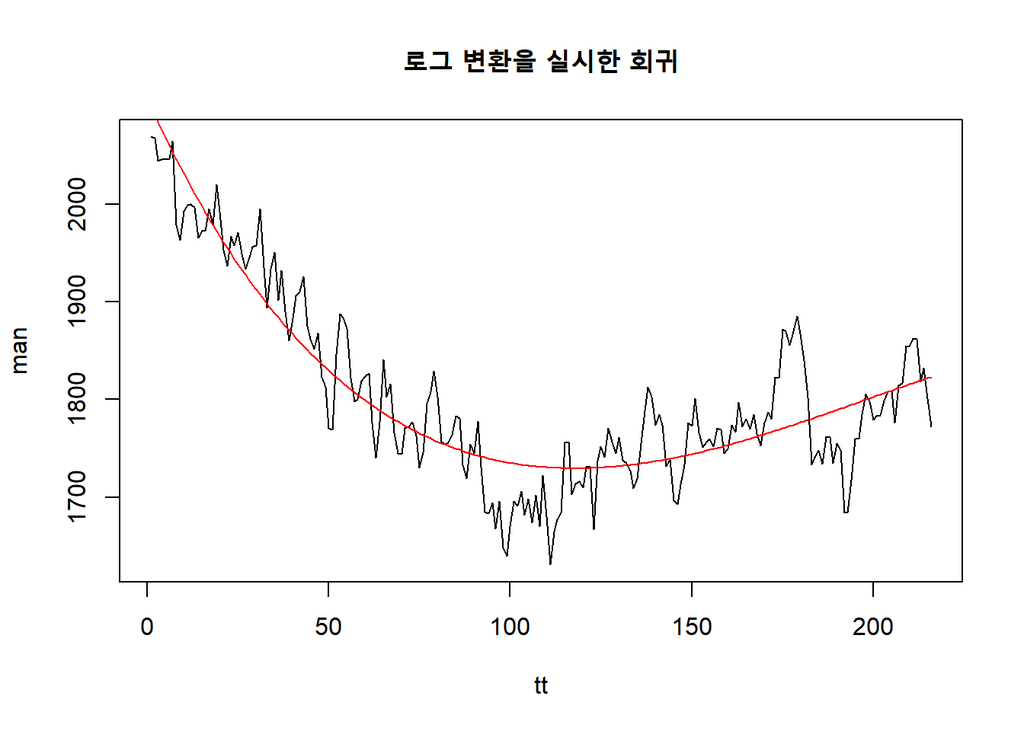

```r
reg4 = lm(log(man)~tt+I(tt^2)+I(tt^3))

plot(tt, man, main='로그 변환을 실시한 회귀', type="l")
lines(exp(reg4$fitted.values), col="red")
```

- 잔차제곱합을 이용한 모형 비교
- sse의 크기를 비교한 결과, 3차 회귀분석이 가장 적절한 것으로 판단된다.

```r
sse1 = sum(reg1$residuals^2) # reg1의 잔차제곱합
sse2 = sum(reg2$residuals^2) # reg2의 잔차제곱합
sse3 = sum((man-exp(reg4$fitted.values))^2) # reg4의 잔차제곱합
c(sse1, sse2, sse3)
```

```
## [1] 395777.6 344148.7 354480.4
```

```r
train_data = window(man, start=c(2005,1), end=c(2020,12))
test_data = window(man, start=c(2021,1), end=c(2022,12))

# 2차 회귀분석
regA = lm(man~tt+I(tt^2))
predA = as.data.frame(test_data) - predict(regA, newdata =test_data) # A모형을 사용했을 때 test 데이터에 대한 예측오차 계산

# 3차 회귀분석
regB = lm(man~tt+I(tt^2)+I(tt^3))
predB = as.data.frame(test_data) - predict(regB, newdata =test_data) # B모형을 사용했을 때 test 데이터에 대한 예측오차 계산

# 로그변환(3차 회귀분석)
regC = lm(log(man)~tt+I(tt^2)+I(tt^3))
predC = as.data.frame(test_data) - exp(predict(regC, newdata =test_data)) # C모형을 사용했을 때 test 데이터에 대한 예측오차 계산
```

```r
# 모형 비교
pred.err = cbind(predA, predB, predC)
acc = colMeans(pred.err^2)
acc
```

```
##     남자     남자     남자
## 44280.84 53548.64 55086.89
```

- 2차 모형한 모형과 로그변환한 2차 모형에 대한 예측오차 비교
- 로그변환 한 것보다 그냥 2차모형만 사용한 것이 예측오차가 더 작은 것으로 확인가능하다.
- 따라서 20대 남성에 대해서는 주어진 모형을 어느정도 잘 설명하고 있고, 예측 또한 매우 우수한 2차 모형을 사용하는 것이 가장 좋은 모형이라고 판단 할 수 있음

```r
regD = lm(log(man)~tt+I(tt^2))
predD = as.data.frame(test_data) - exp(predict(regD, newdata =test_data)) # D모형을 사용했을 때 test 데이터에 대한 예측오차 계산

pred.err = cbind(predA, predD)
bdd = colMeans(pred.err^2)
bdd
```

```
##     남자     남자
## 44280.84 45445.35
```

#### (2) 회귀를 이용한 추세 분석 (여성)

- 남성과 마찬가지로 시계열 그래프 개형을 살펴봤을 때, 직선적인 추세를 띠고 있지 않아서 2차 회귀분석부터 4차, 그리고 3차 회귀에 로그변환을 적용한 모형까지 고려해보았다.

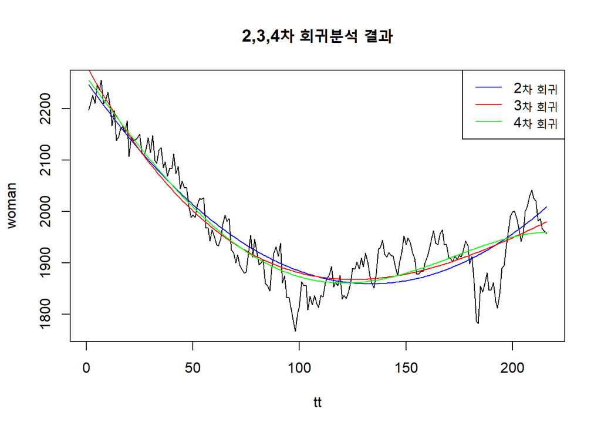

```r
tt = 1:length(woman) # 설명변수
reg1 = lm(woman~tt+I(tt^2))
reg2 = lm(woman~tt+I(tt^2)+I(tt^3))
reg3 = lm(woman~tt+I(tt^2)+I(tt^3)+I(tt^4))

plot(tt, woman, main='2,3,4차 회귀분석 결과', type="l")
lines(reg1$fitted.values, col="blue")
lines(reg2$fitted.values, col="red")
lines(reg3$fitted.values, col="green")
legend("topright", legend=c("2차 회귀", "3차 회귀", "4차 회귀"), col=c("blue", "red", "green"), lty=1)
```

- 회귀모형의 유의성검정
- 남성과 마찬가지로 여성 역시 2차, 3차, 4차 다항회귀분석에 대하여 추세분석을 진행한 후 각각 독립변수들이 유의한 결과가 나오는지를 확인하기 위해 유의성 검정을 실시하였다.
- 유의수준 0.05하에서 2차, 3차 회귀분석은 모든 변수들이 유의한 결과가 나오는 것을 확인할 수 있지만 4차 회귀분석에서는 이차항 독립변수가 유의하지 않은 결과가 나오는 것을 확인할 수 있다.
- 따라서 해당 데이터에 대해서는 3차 모형까지가 적합한 모형으로 판단한 후 3차모형에 로그변환을 한 것까지 같이 비교해 보았다.

```r
sreg1 = summary(reg1) # 2차
sreg2 = summary(reg2) # 3차
sreg3 = summary(reg3) # 4차

print(sreg1$coefficients)
```

```
##                  Estimate   Std. Error   t value      Pr(>|t|)
## (Intercept) 2252.63779975 9.1451094597 246.32158 1.439831e-263
## tt            -5.88653004 0.1945960725 -30.24999  4.799252e-79
## I(tt^2)        0.02203247 0.0008685323  25.36748  2.723619e-66
```

```r
print(sreg2$coefficients)
```

```
##                  Estimate   Std. Error    t value      Pr(>|t|)
## (Intercept)  2.283571e+03 1.190540e+01 191.809659 1.253286e-239
## tt          -7.577623e+00 4.740366e-01 -15.985313  2.881038e-38
## I(tt^2)      4.147019e-02 5.069848e-03   8.179770  2.598204e-14
## I(tt^3)     -5.971648e-05 1.535972e-05  -3.887862  1.352820e-04
```

```r
print(sreg3$coefficients)
```

```
##                  Estimate   Std. Error     t value      Pr(>|t|)
## (Intercept)  2.260888e+03 1.485737e+01 152.1728072 1.159626e-217
## tt          -5.529572e+00 9.440496e-01  -5.8572897  1.786227e-08
## I(tt^2)     -7.724231e-04 1.763354e-02  -0.0438042  9.651019e-01
## I(tt^3)      2.426299e-04 1.219599e-04   1.9894238  4.794595e-02
## I(tt^4)     -6.966507e-07 2.788303e-07  -2.4984756  1.323595e-02
```

- 3차 회귀모형에 로그변환을 적용한 모형

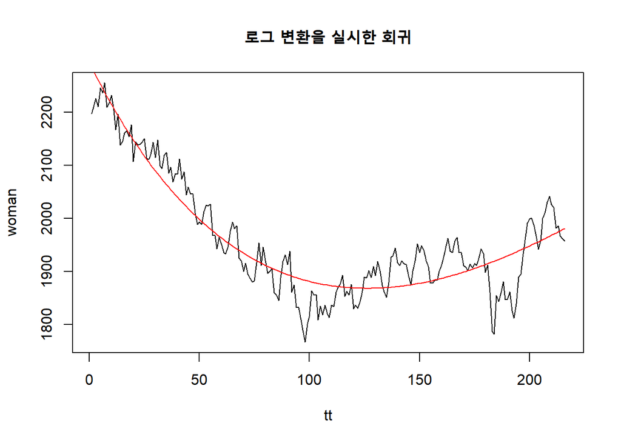

```r
reg4 = lm(log(woman)~tt+I(tt^2)+I(tt^3))
plot(tt, woman, main='로그 변환을 실시한 회귀', type="l")
lines(exp(reg4$fitted.values), col="red")
```

- 잔차제곱합을 이용한 모형 비교
- sse의 크기를 비교한 결과, 3차 회귀분석이 가장 적절한 것으로 판단된다.

```r
sse1 = sum(reg1$residuals^2) # reg1의 잔차제곱합
sse2 = sum(reg2$residuals^2) # reg2의 잔차제곱합
sse3 = sum((woman-exp(reg4$fitted.values))^2) # reg4의 잔차제곱합
c(sse1, sse2, sse3)
```

```
## [1] 419663.5 391733.2 400470.9
```

```r
train_data = window(woman, start=c(2005,1), end=c(2020,12))
test_data = window(woman, start=c(2021,1), end=c(2022,12))

# 2차 회귀분석
regA = lm(woman~tt+I(tt^2))
predA = as.data.frame(test_data) - predict(regA, newdata =test_data) # A모형을 사용했을 때 test 데이터에 대한 예측오차 계산

# 3차 회귀분석
regB = lm(woman~tt+I(tt^2)+I(tt^3))
predB = as.data.frame(test_data) - predict(regB, newdata =test_data) # B모형을 사용했을 때 test 데이터에 대한 예측오차 계산

# 로그변환(3차 회귀분석)
regC = lm(log(woman)~tt+I(tt^2)+I(tt^3))
predC = as.data.frame(test_data) - exp(predict(regC, newdata =test_data)) # C모형을 사용했을 때 test 데이터에 대한 예측오차 계산


# 모형 비교
pred.err = cbind(predA, predB, predC)
acc = colMeans(pred.err^2)
acc
```

```
##     여자     여자     여자
## 55151.57 62631.51 64355.34
```

- 2차 모형과 로그변환한 2차모형에 대한 예측오차 비교
- 로그변환 한 것보다 그냥 2차모형만 사용한 것이 예측오차가 더 작은 것으로 확인가능하다.
- 따라서 20대 여성에 대해서도 마찬가지로 주어진 모형을 어느정도 잘 설명하고 있고, 예측 또한 매우 우수한 2차 모형을 사용하는 것이 가장 좋은 모형이라고 판단 할 수 있다.

```r
regD = lm(log(woman)~tt+I(tt^2))
predD = as.data.frame(test_data) - exp(predict(regD, newdata =test_data)) # D모형을 사용했을 때 test 데이터에 대한 예측오차 계산

pred.err = cbind(predA, predD)
bdd = colMeans(pred.err^2)
bdd
```

```
##     여자     여자
## 55151.57 56950.17
```

## 3. 평활법

#### (1) 평활법 목적

- 평활법은 데이터의 추세를 파악하기 위한 방법 중 하나로써 본 1차 보고서에서는 원본 데이터에 평활법을 적용하여 대략적인 추체를 파악하는 것을 목적으로 한다.
- 이동평균법, 지수평활법, 국소회귀를 활용해 평활법을 적용해 가장 적합한 기법을 탐색하고자 한다.

#### (2) 이동평균법

(2-1) 단순이동평균법을 활용한 이동평균법

```r
man_ma <- ma(man,order=12,centre=TRUE) # 중심화 이동평균
man_ma_nocenter <- ma(man,order=12,centre=FALSE)
woman_ma <- ma(woman,order=12,centre=TRUE) # 중심화 이동평균
woman_ma_nocenter <- ma(woman,order=12,centre=FALSE)
```

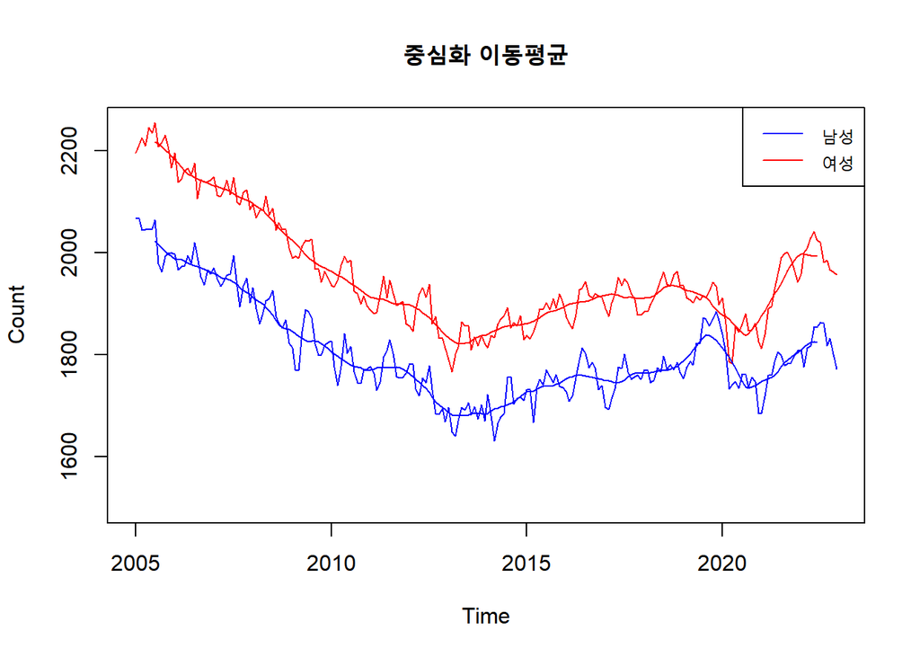

```r
plot(man, main="중심화 이동평균", col="blue", ylab='Count', ylim=c(1500, max(woman)))
lines(woman, col="red")
lines(man_ma,col="blue")
lines(woman_ma,col="red")
legend("topright", legend=c("남성", "여성"), col=c("blue", "red"), lty=1)
```

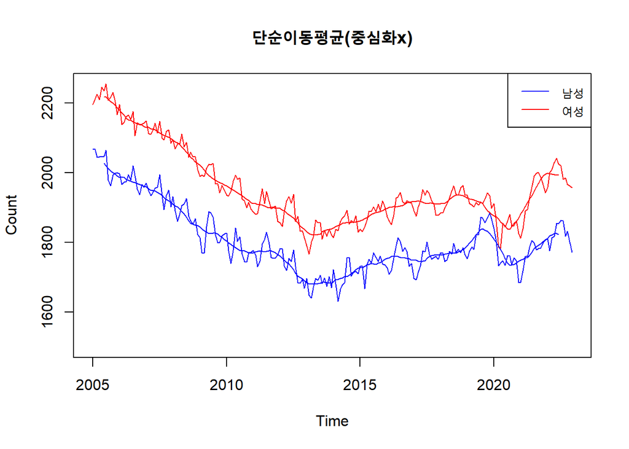

```r
plot(man, main="단순이동평균(중심화x)", col="blue", ylab='Count', ylim=c(1500, max(woman)))
lines(woman, col="red")
lines(man_ma_nocenter, col='blue')
lines(woman_ma_nocenter, col='red')
legend("topright", legend=c("남성", "여성"), col=c("blue", "red"), lty=1)
```

(2-2) 이중이동평균법을 활용한 이동평균법

```r
dma <- function(x, n){ # 이중 이동평균 함수 정의
  ma <- ma(x,order=12,centre=TRUE)
  dma <- filter(ma, rep(1/n, n), sides=2)
  return(dma)
}

smoothed_man <- dma(man, 12)
smoothed_woman <- dma(woman, 12)
```

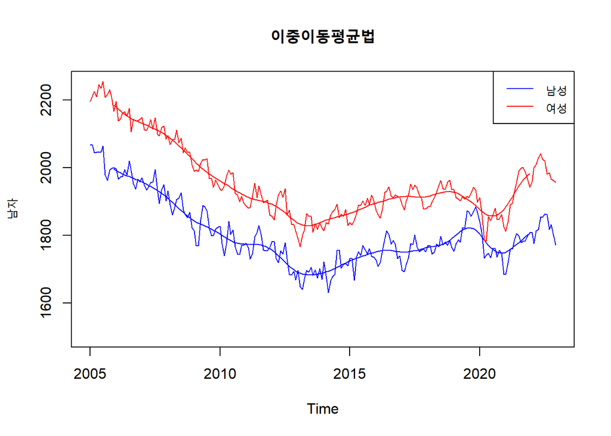

```r
plot(man,main="이중이동평균법",col='blue', ylim=c(1500, max(woman)))
lines(smoothed_man,col='blue')
lines(woman,col='red')
lines(smoothed_woman, col="red")
legend("topright", legend=c("남성", "여성"), col=c("blue", "red"), lty=1)
```

- 단순이동평균법, 이중이동평균법을 적용했을 때 모두 적절하게 평활이 된 것을 확인할 수 있다.

#### (3) 지수평활법

- 지수평활법에는 단순지수평활, 선형지수평활, 계절지수평활이 존재하나 본 보고서에서는 예측이 아닌 추세파악을 하는 것이 목적이므로 단순지수평활만을 이용해 그 결과를 시각화해보았다.

(3-1) 단순지수평활법

- 평활상수 alpha는 0.1부터 0.9까지 시행해본 결과, 0.2일 때 평활이 가장 잘된 것을 볼 수 있었다.
- alpha=0.2로 지정하여 단순지수평활법을 실행한 그래프는 다음과 같다.

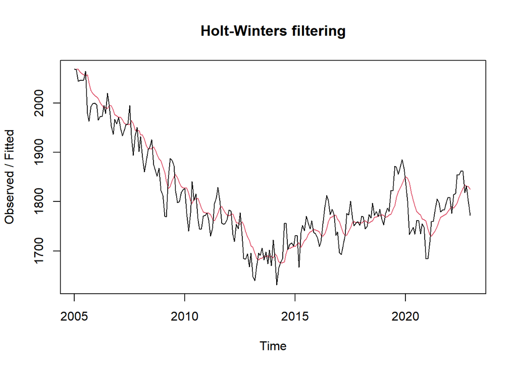

```r
plot(HoltWinters(man,alpha=0.2,beta=FALSE,gamma=FALSE))
```

4. 국소회귀
- 국소회귀를 활용해 남녀 각각 평활했을 때, 대체적으로 추세를 대표하는 것으로 판단할 수 있다.
- 하지만 국소회귀는 미래 시점에 대한 예측이 불가능하다.

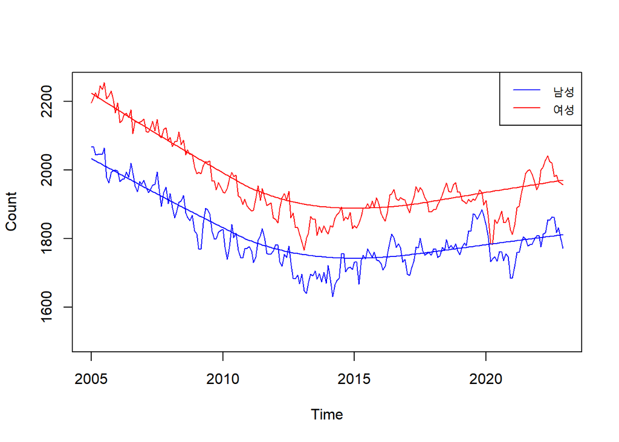

```r
man_lowess <- lowess(man,f=2/3)
woman_lowess <- lowess(woman,f=2/3)

plot(man, col="blue", ylab='Count', ylim=c(1500, max(woman)))
lines(woman, col="red")
lines(man_lowess,col='blue')
lines(woman_lowess,col='red')
legend("topright", legend=c("남성", "여성"), col=c("blue", "red"), lty=1)
```

## 4. 분해법

- 해당 시계열 데이터를 분해하기 앞서, 시계열 데이터를 구성하는 성분은 추세,계절,불규칙 성분만을 고려한다.
- 남녀 관측치들을 시계열 그림으로 확인해본 결과, 시점에 따른 데이터의 진폭이 일정하지 않기에 남녀 데이터 모두 각 성분의 결합방식이 승법모형이라고 가정하고 분해를 진행하고자 한다.

```r
dec.m <- decompose(man,type="multiplicative")
dec.w <- decompose(woman,type="multiplicative")
```

- 시계열 그림을 통해 확인해본 결과, 데이터의 패턴 파악이 어려우므로 남녀 데이터 모두 추세모형을 이용한 추세성분 추정 보다는 중심화 이동평균을 이용하여 추세성분 추정하였다. (이동평균기간은 주기의 최소배수)

```r
head(dec.m$trend, 10)
```

```
##           Jan      Feb      Mar      Apr      May      Jun      Jul      Aug
## 2005       NA       NA       NA       NA       NA       NA 2023.583 2016.333
##           Sep      Oct
## 2005 2009.125 2003.125
```

```r
head(dec.w$trend, 10)
```

```
##           Jan      Feb      Mar      Apr      May      Jun      Jul      Aug
## 2005       NA       NA       NA       NA       NA       NA 2217.542 2214.375
##           Sep      Oct
## 2005 2207.875 2202.458
```

- 추세조정된 시계열 데이터를 바탕으로, 계절성분 추정. 두 데이터의 추정된 계절성분의 값을 확인해보면, 성별간 취업자 데이터의 계절성분 값은 크게 차이나지 않는다.
- 위에서 추정된 추세성분과 계절성분을 조정하여 불규칙성분 추정할 수 있다.

```r
head(dec.m$seasonal,10)
```

```
##            Jan       Feb       Mar       Apr       May       Jun       Jul
## 2005 0.9988767 0.9885586 0.9805197 0.9924076 1.0098309 1.0091419 1.0225412
##            Aug       Sep       Oct
## 2005 1.0057531 0.9957678 0.9982407
```

```r
head(dec.w$seasonal,10)
```

```
##            Jan       Feb       Mar       Apr       May       Jun       Jul
## 2005 0.9895379 0.9848602 0.9894598 0.9984601 1.0126642 1.0087989 1.0174666
##            Aug       Sep       Oct
## 2005 1.0011661 1.0030616 1.0009293
```

- 남녀 시계열 데이터에 대한 각각의 분해법 진행 결과

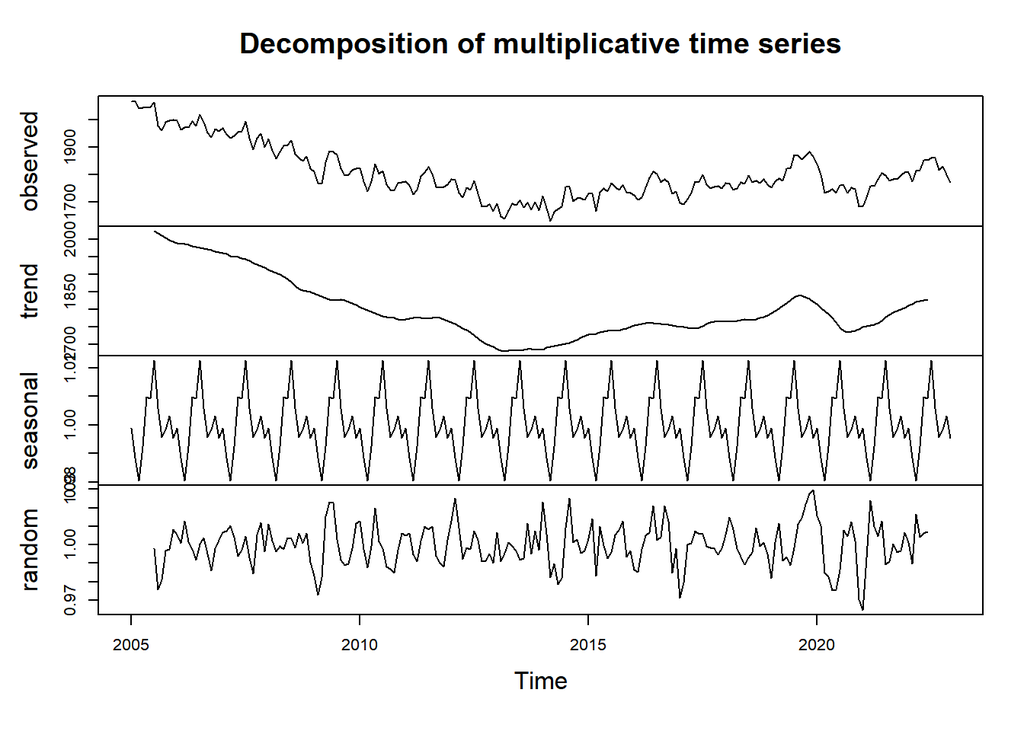

```r
plot(dec.m)
```

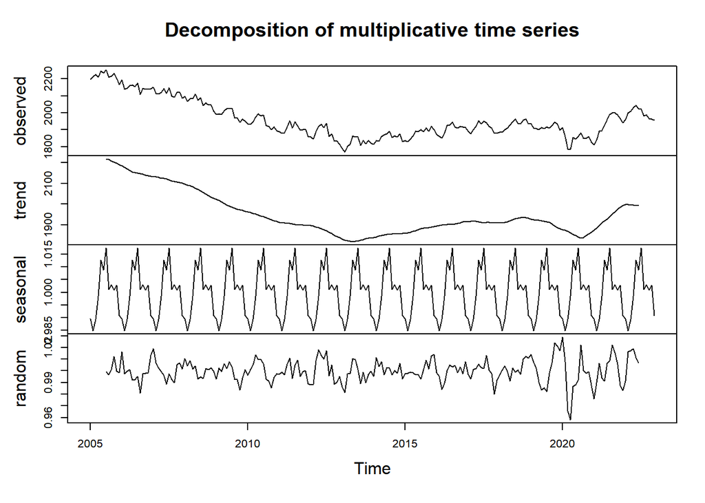

```r
plot(dec.w)
```

## 5. 결론 및 요약

- 1차 보고서는 ARIMA 모형 적합을 위한 데이터의 탐색과 근거를 찾는 것을 목적으로 하고 있다.
- 두 시계열 데이터 모두 2차 회귀모형을 적합하였을 때, 추세를 잘 설명하고 예측 또한 잘할 수 있을 것이라고 판단된다.
- 여러 기법을 활용해 평활한 결과, 이동평균법이 가장 합리적으로 평활된 모습을 확인할 수 있다.
- 원본 데이터에 분해법을 적용한 결과를 확인해보았는데, 추후 정상화 변형된 모형과의 비교를 해볼 필요가 있을 것으로 판단된다.
- 남성과 여성 모두 시계열 그래프를 파악한 결과, 비정상성을 띤다고 판단하였지만 추후 단위근 검정을 이용하여 차분이 필요한 비정상시계열 여부를 명확하게 파악할 예정이다.